# Welcome to the Tidyverse

# Set-up - carichiamo i pacchetti

## Tidyverse

Come prima cosa carichiamo il pacchetto tidyverse:

```r
library(tidyverse)
```

Come vedete il pacchetto è in realtà un pacchetto di pacchetti. Quando caricate tidyverse in realtà state caricando tutti i pacchetti sottostanti. Alcuni li conoscete già come `ggplot2`. Nella sezione conflicts vi avverte che ci sono delle funzioni da pacchetti differenti hanno lo stesso nome. Ora se usassimo la funzione `filter()` non richiameremmo la funzione dal pacchetto stats, ma quella dal pacchetto `dplyr`. Curiosità: per essere sicuri di usare la funzione dal pacchetto giusto possiamo usare la notazione `pacchetto::funzione()`.

## Penguins

Il secondo pacchetto che useremo sarà `palmerpenguins`, è un pacchetto di dati (contiene solo dati non funzioni).

```r
library(palmerpenguins)
```

Questo ci da accesso al dataframe `penguins`, che sono dati relativi a un campione di tre diverse specie di pinguini abitanti l’arcipelago Palmer in Antartide:

```r
penguins
```

| species | island | bill_length_mm | bill_depth_mm | flipper_length_mm | body_mass_g | sex | year |
| --- | --- | --- | --- | --- | --- | --- | --- |
| Adelie | Torgersen | 39.1 | 18.7 | 181 | 3750 | male | 2007 |
| Adelie | Torgersen | 39.5 | 17.4 | 186 | 3800 | female | 2007 |
| Adelie | Torgersen | 40.3 | 18.0 | 195 | 3250 | female | 2007 |
| Adelie | Torgersen | NA | NA | NA | NA | NA | 2007 |
| Adelie | Torgersen | 36.7 | 19.3 | 193 | 3450 | female | 2007 |
| Adelie | Torgersen | 39.3 | 20.6 | 190 | 3650 | male | 2007 |
| Adelie | Torgersen | 38.9 | 17.8 | 181 | 3625 | female | 2007 |
| Adelie | Torgersen | 39.2 | 19.6 | 195 | 4675 | male | 2007 |
| Adelie | Torgersen | 34.1 | 18.1 | 193 | 3475 | NA | 2007 |
| Adelie | Torgersen | 42.0 | 20.2 | 190 | 4250 | NA | 2007 |

[output cut: 334 more lines]

bene, ora con i dati alla mano vediamo cosa possiamo fare con il tidyverse!

# Pipe e short-cuts

## Pipe

Prima di iniziare è bene conoscere certe short-cut che ci consentono di lavorare meglio e più velocemente con R.

La prima funzione che vediamo è la pipe (`%>%` oppure `|>`). La pipe è una funzione che ci consente di utilizzare al meglio le funzioni del tidyverse, ma in generale anche R. All’inizio è un po’ controintuitiva, ma una volta capito come funziona facilita notevolmente la nostra vita.

Come funziona? La pipe passa l’oggetto che sta alla sua sinistra (che può essere un dataframe, un array, ecc.) alla funzione che sta alla sua destra come primo argomento della stessa. Vediamo un esempio con la funzione `mean()`. Con R normale per calcolare la media di un vettore devo scrivere prima la funzione poi i dati:

```r
mean( c(1,4,6,7,3) )
```

```
## [1] 4.2
```

Con la pipe scrivo prima i dati e poi la funzione che voglio applicargli:

```r
c(1,4,6,7,3) %>% mean()
```

```
## [1] 4.2
```

Non cambia molto voi direte. In realtà, se ci pensate se devo applicare una serie di funzioni ai miei dati con R ho due scelte: o applico le funzioni aggiungendo continuamente prefissi ai miei dati o creo una serie di dummy variables a cui continuo ad applicare le mie funzioni, sprecando memoria. Ad esempio, se al mio array volessi:

1. normalizzare
2. elevare e alla x potenza
3. calcolare la media

```r
mean( exp( scale( c(1, 4, 6, 7, 3) ) ) )
```

```
## [1] 1.428538
```

con R normale se volessi fare tutto in un passaggio ottengo una serie di funzioni e tante parentesi tonde che non so più a quale funzione appartengano. Inoltre non ho spazio per commenti ed è difficile interpretare il codice in un secondo tempo.

Con la pipe il tutto diventa molto più intuitivo:

```r
c(1, 4, 6, 7, 3) %>% # prendo il vettore e lo passo alla funzione scale
  scale() %>% # il risultato lo passo alla funzione exp
  exp() %>% # il risultato lo passo alla funzione mean
  mean()
```

```
## [1] 1.428538
```

il tutto può anche essere messo in una singola riga, ma se c’è bisogno di fare più di una operazione è meglio andare a capo (il codice viene più ordinato). Il vantaggio principale di lavorare con la pipe infatti è che ci consente di lavorare con un approccio progressivo invece che ricorsivo.

Nota Bene: il primo argomento di tutte le fuznioni usate sono appunto array di dati. Non sempre è così. Ad esempio la funzione `lm()` come primo argomento prende la formula, non i dati. Se passo i dati a `lm()` con la pipe mi darà errore:

```
data.frame(x = c(1,2,3,4,5), y = c(2.1,3.1,4,4.9,6)) %>%
  lm(y~x) # restituisce errore
```

In questo caso dovrò specificare dove i miei dati vanno inseriti con il punto `.` :

```r
data.frame(x = c(1,2,3,4,5), y = c(2.1,3.1,4,4.9,6)) %>%
  lm(data = ., formula = y~x) # in questo modo non restituisce errore e dà il risultato che voglio
```

```
##
## Call:
## lm(formula = y ~ x, data = .)
##
## Coefficients:
## (Intercept)            x
##        1.14         0.96
```

E se volessi direttamente il summary:

```r
data.frame(x = c(1,2,3,4,5), y = c(2.1,3.1,4,4.9,6)) %>%
  lm(data = ., formula = y~x) %>%
  summary()
```

```
##
## Call:
## lm(formula = y ~ x, data = .)
##
## Residuals:
##          1          2          3          4          5
##  7.772e-16  4.000e-02 -2.000e-02 -8.000e-02  6.000e-02
##
## Coefficients:
##             Estimate Std. Error t value Pr(>|t|)
## (Intercept)  1.14000    0.06633   17.19 0.000429 ***
## x            0.96000    0.02000   48.00 1.99e-05 ***
## ---
## Signif. codes:  0 '***' 0.001 '**' 0.01 '*' 0.05 '.' 0.1 ' ' 1
##
## Residual standard error: 0.06325 on 3 degrees of freedom
## Multiple R-squared:  0.9987, Adjusted R-squared:  0.9983
## F-statistic:  2304 on 1 and 3 DF,  p-value: 1.991e-05
```

## Short cuts

Ci sono dei comandi rapidi da tastiera per agevolare l’utilizzo di R:

- F1 –> aiuto sulla funzione in cui è il cursore
- Tab –> completamento automatico/suggerimenti
- Ctrl/Cmd + Shift + M –> Inserisci una pipe ( %>% )
- Ctrl/Cmd + Invio –> Esegue la riga in cui sta il cursore (e le righe collegate) o il codice selezionato
- Ctrl/Cmd + Shift + Invio –> Esegue tutto il chunk in cui è il cursore
- Ctrl+Alt+I / Cmd+Option+I –> Inserisce un nuovo chunk dov’è il cursore
- Ctrl/Cmd + Shift + F10 –> Restart R (NB: dovrò ricaricare tutti i pacchetti)

In particolare il comando rapido per le pipe e quello dell’esecuzione del codice se usati insieme sono molto potenti.

# Tidying the data

Diamo un occhio ai dati. Il tidyverse è ottimizzato per lavorare con i data.frame, o meglio con le tibble che sono praticamente equivalenti ai data frame. Con la funzione `glimpse()` possiamo visulaizzare velocemente tutte le colonne e il tipo di dato contenuto in esse.

```r
penguins %>% glimpse()
```

```
## Rows: 344
## Columns: 8
## $ species           <fct> Adelie, Adelie, Adelie, Adelie, Adelie, Adelie, Adel…
## $ island            <fct> Torgersen, Torgersen, Torgersen, Torgersen, Torgerse…
## $ bill_length_mm    <dbl> 39.1, 39.5, 40.3, NA, 36.7, 39.3, 38.9, 39.2, 34.1, …
## $ bill_depth_mm     <dbl> 18.7, 17.4, 18.0, NA, 19.3, 20.6, 17.8, 19.6, 18.1, …
## $ flipper_length_mm <int> 181, 186, 195, NA, 193, 190, 181, 195, 193, 190, 186…
## $ body_mass_g       <int> 3750, 3800, 3250, NA, 3450, 3650, 3625, 4675, 3475, …
## $ sex               <fct> male, female, female, NA, female, male, female, male…
## $ year              <int> 2007, 2007, 2007, 2007, 2007, 2007, 2007, 2007, 2007…
```

con questa funzione possiamo velocemente capire se alcune colonne necessitano di modifiche. Ad esempio, se ho una colonna di dati numerici che è segnata come colonna di caratteri so già che c’è qualcosa che non va e andrà sistemato.

### Filter

Vediamo come le prime due colonne sono variabili categoriche (factor), le seconde due sono numeri con cifra decimale, poi due colonne di numeri interi, ecc. A occhio notiamo che ci sono anche NA nei dati… Potrebbero essere un problema per alcune analisi. Vediamo quali sono le righe problematiche con il comando `filter()`:

```r
penguins %>%
  # tienimi tutte le righe che hanno NA, ovvero che non (! = operatore NOT) sono casi completi
  filter(! complete.cases(.))
```

| species | island | bill_length_mm | bill_depth_mm | flipper_length_mm | body_mass_g | sex | year |
| --- | --- | --- | --- | --- | --- | --- | --- |
| Adelie | Torgersen | NA | NA | NA | NA | NA | 2007 |
| Adelie | Torgersen | 34.1 | 18.1 | 193 | 3475 | NA | 2007 |
| Adelie | Torgersen | 42.0 | 20.2 | 190 | 4250 | NA | 2007 |
| Adelie | Torgersen | 37.8 | 17.1 | 186 | 3300 | NA | 2007 |
| Adelie | Torgersen | 37.8 | 17.3 | 180 | 3700 | NA | 2007 |
| Adelie | Dream | 37.5 | 18.9 | 179 | 2975 | NA | 2007 |
| Gentoo | Biscoe | 44.5 | 14.3 | 216 | 4100 | NA | 2007 |
| Gentoo | Biscoe | 46.2 | 14.4 | 214 | 4650 | NA | 2008 |
| Gentoo | Biscoe | 47.3 | 13.8 | 216 | 4725 | NA | 2009 |
| Gentoo | Biscoe | 44.5 | 15.7 | 217 | 4875 | NA | 2009 |

[output cut: 1 more lines]

`filter()` è una funzione potente che ci consente di selezionare le righe in base a criteri sulle variabili del dataframe. Ad esempio possiamo selezionare tutti i pinguini che abitano una determinata isola e hanno un becco con una lunghezza maggiore di 40 mm. La virgola all’interno della funzione funge da operatore AND &. All’interno della funzione possiamo inserire anche altri operatori logici come l’operatore OR |. Possiamo usare anche la funzione `%in%` che equivale all’operatore `==` solo che ci consente di avere più valori possibili per l’uguaglianza (in altre parole “selezionami le righe che contengono almeno uno dei valori”).

```r
penguins %>%
  # tienimi i pinguini che sono presenti nell'isola Dream e che hanno un becco più lungo di 40 mm.
  filter(island == "Dream") %>%
  filter(bill_length_mm > 40) %>%
  # oppure posso scriverli insieame
  # filter(island == "Dream", bill_length_mm > 40 )
  # la virgola funge da operatore logico AND

  # Ora tienimi solo i pinguini dell'anno 2007 o 2009
  filter(year %in% c(2007, 2009))
```

| species | island | bill_length_mm | bill_depth_mm | flipper_length_mm | body_mass_g | sex | year |
| --- | --- | --- | --- | --- | --- | --- | --- |
| Adelie | Dream | 40.9 | 18.9 | 184 | 3900 | male | 2007 |
| Adelie | Dream | 42.2 | 18.5 | 180 | 3550 | female | 2007 |
| Adelie | Dream | 40.8 | 18.4 | 195 | 3900 | male | 2007 |
| Adelie | Dream | 44.1 | 19.7 | 196 | 4400 | male | 2007 |
| Adelie | Dream | 41.1 | 19.0 | 182 | 3425 | male | 2007 |
| Adelie | Dream | 42.3 | 21.2 | 191 | 4150 | male | 2007 |
| Adelie | Dream | 41.1 | 17.5 | 190 | 3900 | male | 2009 |
| Adelie | Dream | 40.2 | 20.1 | 200 | 3975 | male | 2009 |
| Adelie | Dream | 40.2 | 17.1 | 193 | 3400 | female | 2009 |
| Adelie | Dream | 40.6 | 17.2 | 187 | 3475 | male | 2009 |

[output cut: 52 more lines]

```r
  # che equivale a
  # filter(year == 2007 | year == 2009)
```

NB: da notare che non appena comincio a scrivere il nome delle colonne del mio dataframe dopo la pipe R mi suggerisce i titoli! Anche cliccando il tasto Tab ⇆ ottengo i suggerimenti di tutte le colonne presenti nel dataframe e posso selezionare quella di interesse (o cliccare nuovamente Tab).

Con `filter()` sono utili anche le funzioni `str_`, come `str_detect()` che identifica tutte le righe che contengono un determinato pattern di caratteri:

```r
penguins %>%
  # tienimi tutte le righe cha hanno un'isola che contiene "s" nel nome
  filter(str_detect(island, "s"))
```

| species | island | bill_length_mm | bill_depth_mm | flipper_length_mm | body_mass_g | sex | year |
| --- | --- | --- | --- | --- | --- | --- | --- |
| Adelie | Torgersen | 39.1 | 18.7 | 181 | 3750 | male | 2007 |
| Adelie | Torgersen | 39.5 | 17.4 | 186 | 3800 | female | 2007 |
| Adelie | Torgersen | 40.3 | 18.0 | 195 | 3250 | female | 2007 |
| Adelie | Torgersen | NA | NA | NA | NA | NA | 2007 |
| Adelie | Torgersen | 36.7 | 19.3 | 193 | 3450 | female | 2007 |
| Adelie | Torgersen | 39.3 | 20.6 | 190 | 3650 | male | 2007 |
| Adelie | Torgersen | 38.9 | 17.8 | 181 | 3625 | female | 2007 |
| Adelie | Torgersen | 39.2 | 19.6 | 195 | 4675 | male | 2007 |
| Adelie | Torgersen | 34.1 | 18.1 | 193 | 3475 | NA | 2007 |
| Adelie | Torgersen | 42.0 | 20.2 | 190 | 4250 | NA | 2007 |

[output cut: 210 more lines]

Approfondimento: la funzione `filter()` deve contenere al suo interno alla fine della computazione degli argomenti un vettore di TRUE/FALSE con lunghezza equivalente al numero di righe del dataframe. La funzione poi eliminerà tutte le righe corrispondenti ai FALSE. Se ci pensate quando io pongo una colonna uguale ad un determinato valore in R (ad esempio `penguins$island == "Dream"`) R mi restituisce un vettore di TRUE/FALSE. Allo stesso modo `str_detect()` in R base mi restituisce un valore di TRUE/FALSE. Quindi dentro filter posso inserire qualsiasi condizione basta che alla fine ottenga un vettore di TRUE/FALSE con lunghezza pari al numero di righe del dataframe.

### Mutate

Notiamo inoltre che non c’è un ID che identifichi univocamente un determinato pinguino e vorremmo aggiungerlo. La funzione `mutate()` ci consente di modificare il dataframe aggiungendo o modificando le colonne. In questo caso vogliamo aggiungere una colonna chiamiata ID con codice alfanumerico “p###” dove # è n numero.

```r
penguins %>%
  mutate( # alla colonna ID assegni questo. Se non è presente nel dataframe la aggiungi, se è presente la modifichi
    # str_pad() crea una stringa con gli elementi del primo elemento (da 1 a n() che è la lunghezza del dataframe), di una lunghezza pari a width (3) e riempe gli spazi vuoti con pad (in questo caso zeri)
    # paste() unisce due stringhe. sep è la stringa che viene interposta tra le stringhe, nel nostro caso non vogliamo separazione
    ID = paste("p", str_pad(1:n(), width = 3, pad = "0"), sep = ""), .before = species
    )
```

| ID | species | island | bill_length_mm | bill_depth_mm | flipper_length_mm | body_mass_g | sex | year |
| --- | --- | --- | --- | --- | --- | --- | --- | --- |
| p001 | Adelie | Torgersen | 39.1 | 18.7 | 181 | 3750 | male | 2007 |
| p002 | Adelie | Torgersen | 39.5 | 17.4 | 186 | 3800 | female | 2007 |
| p003 | Adelie | Torgersen | 40.3 | 18.0 | 195 | 3250 | female | 2007 |
| p004 | Adelie | Torgersen | NA | NA | NA | NA | NA | 2007 |
| p005 | Adelie | Torgersen | 36.7 | 19.3 | 193 | 3450 | female | 2007 |
| p006 | Adelie | Torgersen | 39.3 | 20.6 | 190 | 3650 | male | 2007 |
| p007 | Adelie | Torgersen | 38.9 | 17.8 | 181 | 3625 | female | 2007 |
| p008 | Adelie | Torgersen | 39.2 | 19.6 | 195 | 4675 | male | 2007 |
| p009 | Adelie | Torgersen | 34.1 | 18.1 | 193 | 3475 | NA | 2007 |
| p010 | Adelie | Torgersen | 42.0 | 20.2 | 190 | 4250 | NA | 2007 |

[output cut: 334 more lines]

da notare che il dataframe penguins non si salva con la pipe. In caso dobbiamo fare noi l’assegnazione. Il suggerimento che io do è fare un dataframe il più completo possibile e salvarlo in memoria, da questo poi è facile selezionare le informazioni che ci servono di volta in volta.

Salviamo quindi penguins modificato nella variabile p1:

```r
p1 <- penguins %>%
  mutate(
    ID = paste("p", str_pad(1:n(), 3, pad = "0"), sep = ""), .before = species
    )
```

`mutate()` mi consente di modificare anche le colonne esistenti. Ad esempio, se voglio modificare la colonna flipper_length assegnandole valore “alto” se ha un valore maggiore-uguale a 197 o “basso” nell’altro caso posso fare così:

```r
penguins %>%
  # modifica il dataframe
  mutate(
    # modifica la colonna flipper length
    flipper_length_mm = ifelse(flipper_length_mm>=197, # test
                               "alto", # valore assegnato se vero
                               "basso" # valore assegnato se falso
                               )
  )
```

| species | island | bill_length_mm | bill_depth_mm | flipper_length_mm | body_mass_g | sex | year |
| --- | --- | --- | --- | --- | --- | --- | --- |
| Adelie | Torgersen | 39.1 | 18.7 | basso | 3750 | male | 2007 |
| Adelie | Torgersen | 39.5 | 17.4 | basso | 3800 | female | 2007 |
| Adelie | Torgersen | 40.3 | 18.0 | basso | 3250 | female | 2007 |
| Adelie | Torgersen | NA | NA | NA | NA | NA | 2007 |
| Adelie | Torgersen | 36.7 | 19.3 | basso | 3450 | female | 2007 |
| Adelie | Torgersen | 39.3 | 20.6 | basso | 3650 | male | 2007 |
| Adelie | Torgersen | 38.9 | 17.8 | basso | 3625 | female | 2007 |
| Adelie | Torgersen | 39.2 | 19.6 | basso | 4675 | male | 2007 |
| Adelie | Torgersen | 34.1 | 18.1 | basso | 3475 | NA | 2007 |
| Adelie | Torgersen | 42.0 | 20.2 | basso | 4250 | NA | 2007 |

[output cut: 334 more lines]

### Rename()

La funzione rename ci consente di rinominare le colonne:

```r
p1 %>%
  rename(# nuovo nome = nome colonna,
         bl = bill_length_mm,
         bd = bill_depth_mm,
         fl = flipper_length_mm,
         m = body_mass_g)
```

| ID | species | island | bl | bd | fl | m | sex | year |
| --- | --- | --- | --- | --- | --- | --- | --- | --- |
| p001 | Adelie | Torgersen | 39.1 | 18.7 | 181 | 3750 | male | 2007 |
| p002 | Adelie | Torgersen | 39.5 | 17.4 | 186 | 3800 | female | 2007 |
| p003 | Adelie | Torgersen | 40.3 | 18.0 | 195 | 3250 | female | 2007 |
| p004 | Adelie | Torgersen | NA | NA | NA | NA | NA | 2007 |
| p005 | Adelie | Torgersen | 36.7 | 19.3 | 193 | 3450 | female | 2007 |
| p006 | Adelie | Torgersen | 39.3 | 20.6 | 190 | 3650 | male | 2007 |
| p007 | Adelie | Torgersen | 38.9 | 17.8 | 181 | 3625 | female | 2007 |
| p008 | Adelie | Torgersen | 39.2 | 19.6 | 195 | 4675 | male | 2007 |
| p009 | Adelie | Torgersen | 34.1 | 18.1 | 193 | 3475 | NA | 2007 |
| p010 | Adelie | Torgersen | 42.0 | 20.2 | 190 | 4250 | NA | 2007 |

[output cut: 334 more lines]

particolarmente utile quando nel dataframe di partenza ci sono nomi composti o lunghi.

### Drop_na()

Per rimuovere gli NA possiamo usare la funzione `drop_na()`. Lasciandola senza argomenti la funzione rimuoverà tutte le righe con almeno un NA in una qualsiasi colonna. Indicando la/e colonna/e rimuove le righe con NA solo in quelle colonne.

```r
p1 %>% nrow()
```

```
## [1] 344
```

```r
p1 %>% drop_na() %>% nrow()
```

```
## [1] 333
```

```r
p1 %>% drop_na(bill_length_mm) %>% nrow()
```

```
## [1] 342
```

```r
p1 %>% drop_na(sex, body_mass_g) %>% nrow()
```

```
## [1] 333
```

### rownames_to_column() e column_to_rownames()

Le funzioni `rownames_to_column()` e `column_to_rownames()` ci consentono di trasformare i nomi delle righe del dataframe in colonne e viceversa. Ad esempio:

```r
p1 %>%
  # assegna ai nomi delle righe i valori della colonna ID e rimuovi la colonna ID
  column_to_rownames("ID")
```

|  | species | island | bill_length_mm | bill_depth_mm | flipper_length_mm | body_mass_g | sex | year |
| --- | --- | --- | --- | --- | --- | --- | --- | --- |
| p001 | Adelie | Torgersen | 39.1 | 18.7 | 181 | 3750 | male | 2007 |
| p002 | Adelie | Torgersen | 39.5 | 17.4 | 186 | 3800 | female | 2007 |
| p003 | Adelie | Torgersen | 40.3 | 18.0 | 195 | 3250 | female | 2007 |
| p004 | Adelie | Torgersen | NA | NA | NA | NA | NA | 2007 |
| p005 | Adelie | Torgersen | 36.7 | 19.3 | 193 | 3450 | female | 2007 |
| p006 | Adelie | Torgersen | 39.3 | 20.6 | 190 | 3650 | male | 2007 |
| p007 | Adelie | Torgersen | 38.9 | 17.8 | 181 | 3625 | female | 2007 |
| p008 | Adelie | Torgersen | 39.2 | 19.6 | 195 | 4675 | male | 2007 |
| p009 | Adelie | Torgersen | 34.1 | 18.1 | 193 | 3475 | NA | 2007 |
| p010 | Adelie | Torgersen | 42.0 | 20.2 | 190 | 4250 | NA | 2007 |

[output cut: 334 more lines]

con questo codice ho rimosso la colonna ID, ma tutti i valori al suo interno sono diventati i nomi dele righe del datarfame. Ora faccio l’operazione inversa:

```r
p1 %>%
  column_to_rownames("ID") %>%
  # prendi i nomi delle righe e assegnali ad una nuova colonna chiamata newvar
  rownames_to_column("newvar")
```

| newvar | species | island | bill_length_mm | bill_depth_mm | flipper_length_mm | body_mass_g | sex | year |
| --- | --- | --- | --- | --- | --- | --- | --- | --- |
| p001 | Adelie | Torgersen | 39.1 | 18.7 | 181 | 3750 | male | 2007 |
| p002 | Adelie | Torgersen | 39.5 | 17.4 | 186 | 3800 | female | 2007 |
| p003 | Adelie | Torgersen | 40.3 | 18.0 | 195 | 3250 | female | 2007 |
| p004 | Adelie | Torgersen | NA | NA | NA | NA | NA | 2007 |
| p005 | Adelie | Torgersen | 36.7 | 19.3 | 193 | 3450 | female | 2007 |
| p006 | Adelie | Torgersen | 39.3 | 20.6 | 190 | 3650 | male | 2007 |
| p007 | Adelie | Torgersen | 38.9 | 17.8 | 181 | 3625 | female | 2007 |
| p008 | Adelie | Torgersen | 39.2 | 19.6 | 195 | 4675 | male | 2007 |
| p009 | Adelie | Torgersen | 34.1 | 18.1 | 193 | 3475 | NA | 2007 |
| p010 | Adelie | Torgersen | 42.0 | 20.2 | 190 | 4250 | NA | 2007 |

[output cut: 334 more lines]

In che contesto queste funzioni possono tornarci utili? Immaginiamo di dover calcolare la correlazione tra tutte le veriabili numeriche del dataframe. Per prima cosa dobbiamo selezionare solo le colonne contenenti valori numerici. Per farlo possiamo usare la funzione `where()` all’interno di `select()`. Tale funziona seleziona tutte le colonne che rispettano una determinata condizione, ad esempio con `is.numeric` (NB: non vanno scritte le parentesi tonde) selezioniamo tutte le colonne numeriche, con `is.character` selezioniamo tutte le colonne contenenti testo, con `is.factor` tutte le colonne con fattori, etc. Poi dobbiamo calcolare la correlazione e infine costruire il grafico con i risultati. Per costruire il grafico useremo la funzione ggplot, che vedremo nel dettaglio fra poco.

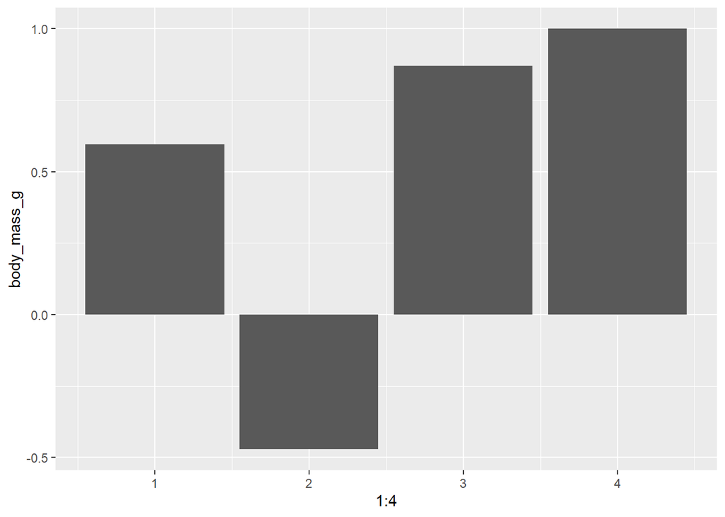

```r
p1 %>%
  # seleziono solo le colonne numeriche
  select(
    where(is.numeric), # selezionami le colonne numeriche
    - year             # rimuovi la colonna year (è numerica, ma non la voglio)
    ) %>%
  # rimuovi tutte le righe con NA
  drop_na() %>%
  # calcola la correlazione
  cor() %>%
  # cor restituisce una matrice; la trasformo in un data.frame
  data.frame() %>%

  # grafico
  ggplot(aes(1:4, body_mass_g)) + geom_col()
```

ok abbiamo ottenuto un grafico, ma non sappiamo cosa è cosa nelle ascisse. Se eseguiamo il codice fino a cor() notiamo che i nomi delle variabili con cui è stata calcolata la correlazione ci sono, ma sono rownames. Qui ci viene in aiuto la funzione `rownames_to_column()`. Infatti, se la inserico prima di costruire il grafico e assegno i nomi delle righe ad una variabile “variable” posso plottare il grafico precedente indicando sulle ascisse cosa è cosa:

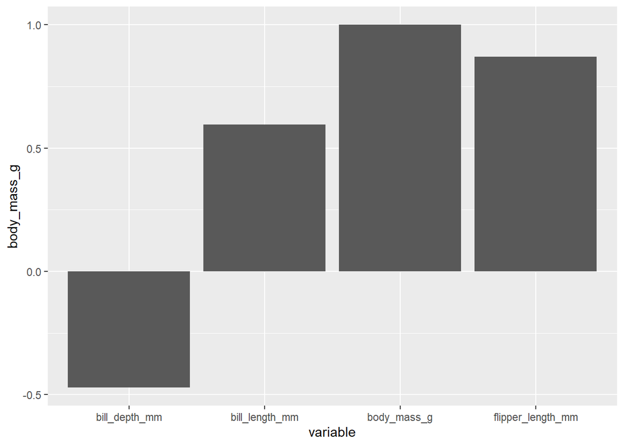

```r
p1 %>%
  select(where(is.numeric), - year) %>%
  drop_na() %>%
  cor() %>%
  data.frame() %>%
  rownames_to_column(var = "variable") %>%
  ggplot(aes(variable, body_mass_g)) + geom_col()
```

# ggplot()

Ora prima di continuare a capire come modificare e lavorare con i dataframe usando il tidyverse, dobbiamo capire come funziona il pacchetto `ggplot2`. Il pacchetto fornisce una serie di funzioni che ci consentono di costruire grafici in maniera semplice, ma allo stesso tempo mantenendo un’ottimo controllo sull’aspetto. Molte delle modifiche che andremo ad operare nei dataframe saranno orientate prorpio ad ottimizzare la struttura dei dati per consentirne la lettura a ggplot.

Vediamo come funziona: la funzione ggplot ha bisogno di due argomenti essenziali che sono i dati (`data`) che possono essere pasasti attraverso la pipe e il `mapping` che viene gestito dalla funzione `aes()`. Nella funzione `aes()` vengono inseriti gli aesthetics ovvero i valori che governeranno il grafico, ad esempio i valori di “x”, “y”, “colour”, “size”, “pch” (aspetto), “alpha”, “group”, etc.

Il modo migliore per usare ggplot è usarlo assieme ai dataframe, infatti possiamo assegnare ai valori dentro aes i nomi delle colonne del dataframe.

Vediamo un esempio con penguins:

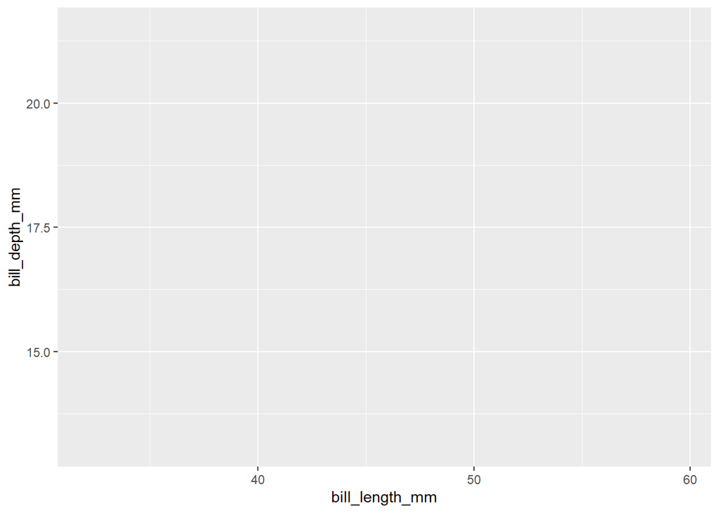

```r
penguins %>%
  # passo alla funzione ggplot il dataframe. La funzione ggplot prende come primo argomento data.
  ggplot(
    mapping = aes(
      x = bill_length_mm, # i valori di x li prendi dalla colonna bill_length_mm
      y = bill_depth_mm   #i valori di y li prendi dalla colonna bill_depth_mm
      )
      )
```

il grafico è vuoto! Perché? Non c’è nulla di sbagliato, solo che ggplot da solo non basta, bisogna dirgli che grafica vogliamo disegnare. Infatti, se notate gli assi hanno nomi delle variabili e valori, è il contenuto del grafico che è vuoto.